# KNN & Logistic Classifiers

Chris Okura

11/12/2021

```r
ins <- read_csv("https://www.dropbox.com/s/aohbr6yb9ifmc8w/heart_attack.csv?dl=1")
ins$output <- as.factor(ins$output)
head(ins)
```

```
## # A tibble: 6 x 8
##     age   sex    cp trtbps  chol restecg thalach output
##   <dbl> <dbl> <dbl>  <dbl> <dbl>   <dbl>   <dbl> <fct>
## 1    63     1     3    145   233       0     150 1
## 2    37     1     2    130   250       1     187 1
## 3    56     1     1    120   236       1     178 1
## 4    57     0     0    120   354       1     163 1
## 5    57     1     0    140   192       1     148 1
## 6    56     0     1    140   294       0     153 1
```

```r
summary(ins)
```

```
##       age             sex              cp             trtbps
##  Min.   :29.00   Min.   :0.000   Min.   :0.0000   Min.   : 94.0
##  1st Qu.:47.00   1st Qu.:0.000   1st Qu.:0.0000   1st Qu.:120.0
##  Median :56.00   Median :1.000   Median :1.0000   Median :130.0
##  Mean   :54.35   Mean   :0.674   Mean   :0.9744   Mean   :132.1
##  3rd Qu.:61.00   3rd Qu.:1.000   3rd Qu.:2.0000   3rd Qu.:140.0
##  Max.   :77.00   Max.   :1.000   Max.   :3.0000   Max.   :200.0
##       chol          restecg          thalach      output
##  Min.   :126.0   Min.   :0.0000   Min.   : 71.0   0:127
##  1st Qu.:211.0   1st Qu.:0.0000   1st Qu.:133.0   1:146
##  Median :240.0   Median :1.0000   Median :152.0
##  Mean   :246.9   Mean   :0.5385   Mean   :149.4
##  3rd Qu.:275.0   3rd Qu.:1.0000   3rd Qu.:166.0
##  Max.   :564.0   Max.   :2.0000   Max.   :202.0
```

## Part One: Fitting Models

### Q1: KNN

### KNN Model 1

```r
knn_mod <- nearest_neighbor(neighbors = 5) %>%
  set_engine("kknn") %>%
  set_mode("classification")

knn_fit_1 <- knn_mod %>%
  fit(output ~ age + chol + trtbps, data = ins)
knn_fit_1$fit %>% summary()
```

```
##
## Call:
## kknn::train.kknn(formula = output ~ age + chol + trtbps, data = data,     ks = min_rows(5, data, 5))
##
## Type of response variable: nominal
## Minimal misclassification: 0.4871795
## Best kernel: optimal
## Best k: 5
```

```r
pred_knn1 <- data.frame(knn_fit_1 %>% predict(ins))
ins <- ins %>%
  mutate(
    pred_knn_1 = pred_knn1[,1]
  )

cm1 <- ins %>%
  count(output, pred_knn_1)
cm1 <- cm1 %>% pivot_wider(names_from = pred_knn_1, values_from = n)
cm1
```

```
## # A tibble: 2 x 3
##   output   `0`   `1`
##   <fct>  <int> <int>
## 1 0        104    23
## 2 1         21   125
```

```r
ins_cvs <- vfold_cv(ins, v = 10)
knn_fit_1_cv <- knn_mod %>%
  fit_resamples(output ~ age + chol + trtbps,
                resamples = ins_cvs)
knn_fit_1_cv %>%
  collect_metrics()
```

```
## # A tibble: 2 x 6
##   .metric  .estimator  mean     n std_err .config
##   <chr>    <chr>      <dbl> <int>   <dbl> <chr>
## 1 accuracy binary     0.491    10  0.0200 Preprocessor1_Model1
## 2 roc_auc  binary     0.528    10  0.0249 Preprocessor1_Model1
```

### KNN Model 2

```r
knn_fit_2 <- knn_mod %>%
  fit(output ~ age + chol + trtbps + cp, data = ins) %>%
  step_dummy(cp)
knn_fit_2$fit %>% summary()
```

```
##
## Call:
## kknn::train.kknn(formula = output ~ age + chol + trtbps + cp,     data = data, ks = min_rows(5, data, 5))
##
## Type of response variable: nominal
## Minimal misclassification: 0.3333333
## Best kernel: optimal
## Best k: 5
```

```r
pred_knn2 <- data.frame(knn_fit_2 %>% predict(ins))
ins <- ins %>%
  mutate(
    pred_knn_2 = pred_knn2[,1]
  )

cm2 <- ins %>%
  count(output, pred_knn_2)
cm2 <- cm2 %>% pivot_wider(names_from = pred_knn_2, values_from = n)
cm2
```

```
## # A tibble: 2 x 3
##   output   `0`   `1`
##   <fct>  <int> <int>
## 1 0        110    17
## 2 1         15   131
```

```r
ins_cvs <- vfold_cv(ins, v = 10)
knn_fit_2_cv <- knn_mod %>%
  fit_resamples(output ~ age + chol + trtbps + cp,
  resamples = ins_cvs) %>%
  step_dummy(cp)

knn_fit_2_cv %>%
  collect_metrics()
```

```
## # A tibble: 2 x 7
##   steps      .metric  .estimator  mean     n std_err .config
##   <list>     <chr>    <chr>      <dbl> <int>   <dbl> <chr>
## 1 <stp_dmmy> accuracy binary     0.670    10  0.0364 Preprocessor1_Model1
## 2 <stp_dmmy> roc_auc  binary     0.721    10  0.0357 Preprocessor1_Model1
```

### KNN Model 3

```r
knn_fit_3 <- knn_mod %>%
  fit(output ~ age + chol + trtbps + cp + restecg, data = ins) %>%
  step_dummy(cp)
knn_fit_3$fit %>% summary()
```

```
##
## Call:
## kknn::train.kknn(formula = output ~ age + chol + trtbps + cp +     restecg, data = data, ks = min_rows(5, data, 5))
##
## Type of response variable: nominal
## Minimal misclassification: 0.3113553
## Best kernel: optimal
## Best k: 5
```

```r
pred_knn3 <- data.frame(knn_fit_3 %>% predict(ins))
ins <- ins %>%
  mutate(
    pred_knn_3 = pred_knn3[,1]
  )

cm3 <- ins %>%
  count(output, pred_knn_3)
cm3 <- cm3 %>% pivot_wider(names_from = pred_knn_3, values_from = n)
cm3
```

```
## # A tibble: 2 x 3
##   output   `0`   `1`
##   <fct>  <int> <int>
## 1 0        115    12
## 2 1         17   129
```

```r
ins_cvs <- vfold_cv(ins, v = 10)
knn_fit_3_cv <- knn_mod %>%
  fit_resamples(output ~ age + chol + trtbps + cp + restecg,
  resamples = ins_cvs) %>%
  step_dummy(cp)
knn_fit_3_cv %>%
  collect_metrics()
```

```
## # A tibble: 2 x 7
##   steps      .metric  .estimator  mean     n std_err .config
##   <list>     <chr>    <chr>      <dbl> <int>   <dbl> <chr>
## 1 <stp_dmmy> accuracy binary     0.680    10  0.0342 Preprocessor1_Model1
## 2 <stp_dmmy> roc_auc  binary     0.730    10  0.0408 Preprocessor1_Model1
```

### Q2: Logistic Regression

### Logistic Model 1

```r
logit_mod <- logistic_reg() %>%
  set_mode("classification") %>%
  set_engine("glm")

ins_rec <- recipe(output ~ age + chol + trtbps, data = ins) %>%
  step_normalize(all_numeric())

ins_wflow_logit <- workflow() %>%
  add_recipe(ins_rec) %>%
  add_model(logit_mod)

ins_fit <- ins_wflow_logit %>%
  fit(ins)

ins_fit %>% extract_fit_parsnip()
```

```
## parsnip model object
##
## Fit time:  0ms
##
## Call:  stats::glm(formula = ..y ~ ., family = stats::binomial, data = data)
##
## Coefficients:
## (Intercept)          age         chol       trtbps
##     0.15083     -0.45576     -0.04589     -0.14000
##
## Degrees of Freedom: 272 Total (i.e. Null);  269 Residual
## Null Deviance:       377.1
## Residual Deviance: 359.7     AIC: 367.7
```

```r
pred_log_1 <- data.frame(ins_fit %>% predict(ins))

ins <- ins %>%
  mutate(
    pred_log_1 = pred_log_1[,1]
  )

cm_log_1 <- ins %>%
  count(output, pred_log_1)
cm_log_1 <- cm_log_1 %>% pivot_wider(names_from = pred_log_1, values_from = n)
cm_log_1
```

```
## # A tibble: 2 x 3
##   output   `0`   `1`
##   <fct>  <int> <int>
## 1 0         72    55
## 2 1         43   103
```

```r
ins_cvs <- vfold_cv(ins, v = 10)
log_fit_1_cv <- ins_fit %>%
  fit_resamples(output ~ age + chol + trtbps,
                resamples = ins_cvs)
log_fit_1_cv %>%
  collect_metrics()
```

```
## # A tibble: 2 x 6
##   .metric  .estimator  mean     n std_err .config
##   <chr>    <chr>      <dbl> <int>   <dbl> <chr>
## 1 accuracy binary     0.623    10  0.0422 Preprocessor1_Model1
## 2 roc_auc  binary     0.649    10  0.0446 Preprocessor1_Model1
```

### Logistic Model 2

```r
ins_rec <- recipe(output ~ age + chol + trtbps + cp, data = ins) %>%
  step_normalize(all_numeric())

ins_wflow_logit <- workflow() %>%
  add_recipe(ins_rec) %>%
  add_model(logit_mod)

ins_fit <- ins_wflow_logit %>%
  fit(ins)

ins_fit %>% extract_fit_parsnip()
```

```
## parsnip model object
##
## Fit time:  20ms
##
## Call:  stats::glm(formula = ..y ~ ., family = stats::binomial, data = data)
##
## Coefficients:
## (Intercept)          age         chol       trtbps           cp
##      0.2016      -0.4160       0.0143      -0.2837       0.9811
##
## Degrees of Freedom: 272 Total (i.e. Null);  268 Residual
## Null Deviance:       377.1
## Residual Deviance: 309.3     AIC: 319.3
```

```r
pred_log_2 <- data.frame(ins_fit %>% predict(ins))

ins <- ins %>%
  mutate(
    pred_log_2 = pred_log_2[,1]
  )

cm_log_2 <- ins %>%
  count(output, pred_log_2)
cm_log_2 <- cm_log_2 %>% pivot_wider(names_from = pred_log_2, values_from = n)
cm_log_2
```

```
## # A tibble: 2 x 3
##   output   `0`   `1`
##   <fct>  <int> <int>
## 1 0         91    36
## 2 1         35   111
```

```r
ins_cvs <- vfold_cv(ins, v = 10)
log_fit_2_cv <- ins_fit %>%
  fit_resamples(output ~ age + chol + trtbps + cp + restecg,
                resamples = ins_cvs)
log_fit_2_cv %>%
  collect_metrics()
```

```
## # A tibble: 2 x 6
##   .metric  .estimator  mean     n std_err .config
##   <chr>    <chr>      <dbl> <int>   <dbl> <chr>
## 1 accuracy binary     0.722    10  0.0196 Preprocessor1_Model1
## 2 roc_auc  binary     0.772    10  0.0270 Preprocessor1_Model1
```

### Q3: Interpretation

ROC curve of KNN Model

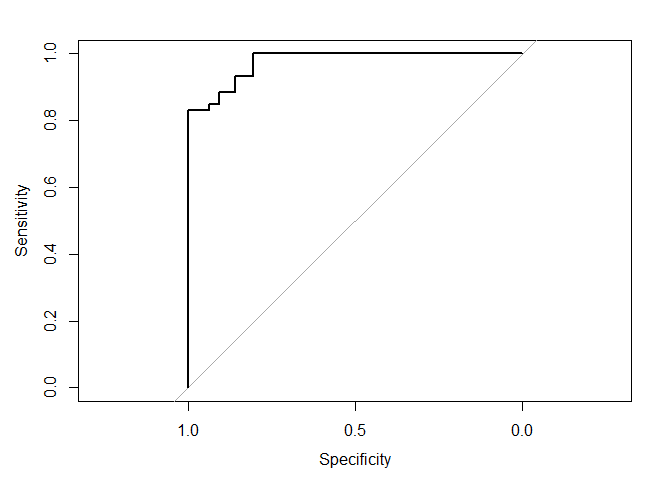

```r
pred_knn_prob3 <- data.frame(knn_fit_3 %>% predict(ins, type = 'prob'))[, 2]
ins <- cbind(ins, pred_knn_prob3)
plot(roc(ins$output, ins[, 14]))
```

ROC curve of logistic model

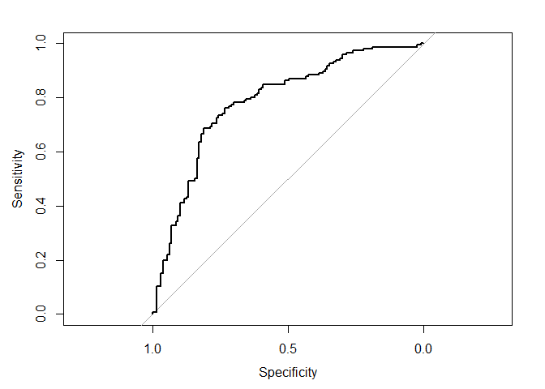

```r
pred_log_2_prob <- data.frame(ins_fit %>% predict(ins, type = "prob"))[, 2]
ins <- cbind(ins, pred_log_2_prob)
plot(roc(ins$output, ins[, 15]))
```

### Part Two: Metrics

True Positive, Precision and True Negative Rate of the KNN model

```r
get_metrics <- function(conf_mat) {
  true_positive <- conf_mat[2, 3]
  positive <- sum(conf_mat[2, 2:3])
  true_pos_rate <- true_positive / positive
  precision <- conf_mat[2, 3] / sum(conf_mat[, 3])
  classified_negative <- sum(conf_mat[, 2])
  true_neg_rate <- conf_mat[1, 2] / classified_negative
  print(true_pos_rate)
  print(precision)
  print(true_neg_rate)
}

get_metrics(cm3)
```

```
##           1
## 1 0.8835616
##           1
## 1 0.9148936
##           0
## 1 0.8712121
```

True Positive of the KNN Model - 88.4% Precision of the KNN Model - 91.5% True Negative Rate of the KNN Model - 87.1%

True Positive, Precision and True Negative Rate of the logistic model

```r
get_metrics(cm_log_1)
```

```
##           1
## 1 0.7054795
##           1
## 1 0.6518987
##          0
## 1 0.626087
```

True Positive of the Logistic Model - 70.5% Precision of the Logistic Model - 65.2% True Negative Rate of the Logistic Model - 62.6%

# Part Three: Discussion

### Q1 The hospital faces severe lawsuits if they deem a patient to be low risk, and that patient later experiences a heart attack.

We want to use the model with the highest true negative rate to avoide the situation where a patient is deemed to be low risk, but later experiences a heart attack. I would use the KNN model with age, chol, trtbps, cp, and restecg as the predictor variables. I would expect an 87% true negative rate from this model.

### Q2 The hospital is overfull, and wants to only use bed space for patients most in need of monitoring due to heart attack risk.

I would use the model with the highest precision rate. In this case we will use the KNN model. I would expect a 91.5% precision rate from this model

### Q3 The hospital is studying root causes of heart attacks, and would like to understand which biological measures are associated with heart attack risk

I would look at the coefficients of the logistic models to determine what factors are important. I would compare adjusted r-squared and AIC to choose a final model.

# Part Four: Validation

```r
ha_validation <- read_csv("https://www.dropbox.com/s/jkwqdiyx6o6oad0/heart_attack_validation.csv?dl=1")
pred_knn_3 <- knn_fit_3 %>% predict(ha_validation)
a <- cbind(ha_validation$output, pred_knn_3) %>%
  group_by(ha_validation$output, .pred_class) %>%
  summarize(n())
names(a) <- c("output", "prediction", "count")
a <- a %>%
  pivot_wider(names_from = prediction, values_from = count)
a
```

```
## # A tibble: 2 x 3
## # Groups:   output [2]
##   output   `0`   `1`
##    <dbl> <int> <int>
## 1      0     7     4
## 2      1     5    14
```

```r
get_metrics(a)
```

```
##           1
## 1 0.7368421
##           1
## 1 0.7777778
##           0
## 1 0.5833333
```

True Positive of the KNN Model on validation data - 73.6% Precision of the KNN Model on validation data - 77.8% True Negative Rate of the KNN Model on validation data - 58.3%

```r
pred_log_2 <- data.frame(ins_fit %>% predict(ha_validation))
a <- cbind(ha_validation$output, pred_log_2) %>%
  group_by(ha_validation$output, .pred_class) %>%
  summarize(n())
names(a) <- c("output", "prediction", "count")
a <- a %>%
  pivot_wider(names_from = prediction, values_from = count)
a
```

```
## # A tibble: 2 x 3
## # Groups:   output [2]
##   output   `0`   `1`
##    <dbl> <int> <int>
## 1      0    10     1
## 2      1     5    14
```

```r
get_metrics(a)
```

```
##           1
## 1 0.7368421
##           1
## 1 0.9333333
##           0
## 1 0.6666667
```

True Positive of the Logistic Model on validation data - 73.6% Precision of the Logistic Model on validation data - 93.3% True Negative Rate of the Logistic Model on validation data - 66.7%

On the validation data, the logistic model performed better, which is the opposite of what we saw from part one.

### Challenge: Cohen’s Kappa

Kappa for the logistic model

```r
library(irr)
kappa2(cbind(pred_log_2, ha_validation$output), weight = "unweighted", sort.levels = FALSE)
```

```
##  Cohen's Kappa for 2 Raters (Weights: unweighted)
##
##  Subjects = 30
##    Raters = 2
##     Kappa = 0.6
##
##         z = 3.41
##   p-value = 0.00065
```

Kappa for the KNN model

```r
kappa2(cbind(pred_knn_3, ha_validation$output), weight = "unweighted", sort.levels = FALSE)
```

```
##  Cohen's Kappa for 2 Raters (Weights: unweighted)
##
##  Subjects = 30
##    Raters = 2
##     Kappa = 0.366
##
##         z = 2.01
##   p-value = 0.0444
```

The Kappa statistic may me more reliable because it takes into account chance agreement due to guessing. Using the Kappa value our prediction is the same.